# Mini_Project3

Nichole, Rowan, Yuqing

11/13/2017

In this miniproject, we chose to answer Professor Keller’s query about the prevalence of original movies in Hollywood in comparison to sequels: reboots, remakes, and adaptations. We chose to group these together, since they all involve the continuation of story, whether it be through the same plot, characters, or world. Through analyzing the IMDb dataset, we hoped to answer the questions: Are more sequels being made today than in the past? How has the ratio of original movies to sequels changed over time? Is the rapidity of a sequel’s release related to its genre? How rapidly are sequels made to Comedy, Horror, and Romance films?

Specifically, we analyzed how the anti-Communist crackdown of the 1950s and the economic crisis of 1981 may have affected the type of films released.

First, we filtered by “mi.info_type_id = 8” and “info=‘USA’” in the index, saving calculation time. Then, we joined the movie_info table three times to determine movies’ genre, production location, and length. Production location and length were limited to made in the U.S. and over 60 minutes in legnth; in doing so we narrowed our search to full Hollywood movies. Fascinatingly, without doing so our data would have looked substantially different because of the proliferation of short films made from 1910-1925, often starring the same characters. These films dramatically shifted the data, but were not relevant to Professor Keller’s question about full-length Hollywood movies. We then used “ml.link_type_id = 2” to make sure all the movies shown were follow up movies of their “related movies”, which was the easiest way to tell which were sequels and which were originals.

```r
library(mdsr)
library(RMySQL)
library(dplyr)
db <- dbConnect_scidb(dbname = "imdb")
big_data<- db%>%
  dbGetQuery("SELECT ml.movie_id, ml.linked_movie_id, ml.link_type_id, t.title AS movie_title, t2.title AS linked_movie_title, t.production_year AS original_year, t2.production_year AS sequels_year, t2.production_year - t.production_year AS year_difference, mi2.info AS genre
FROM movie_link ml
JOIN title t ON ml.movie_id = t.id
JOIN title t2 ON ml.linked_movie_id = t2.id
JOIN movie_info mi On t.id = mi.movie_id
JOIN movie_info mi2 On t.id = mi2.movie_id
JOIN movie_info mi3 On t.id = mi3.movie_id
WHERE ml.link_type_id =2
AND mi.info_type_id = 8
AND mi.info = 'USA'
AND mi2.info_type_id = 3
AND mi2.info IN ('Comedy', 'Horror', 'Romance')
AND mi3.info_type_id = 1
AND mi3.info > 60
AND t.kind_id = 1
AND t2.kind_id = 1;")




d1<- big_data %>%
  group_by(sequels_year) %>%
  summarize(total = n())
d2 <- big_data %>%
  group_by(original_year)%>%
  summarize(total = n())
d3 <- d1%>%
  full_join(d2, by = c("sequels_year" = "original_year"))

#x:sequels, y:original

d4<- d3%>%
  mutate(decade = 10 * floor(sequels_year / 10)) %>%
  group_by(decade)%>%
  summarize(sequels = sum(total.x),
          original = sum(total.y))
d4
```

```
## # A tibble: 13 x 3
##    decade sequels original
##     <dbl>   <int>    <int>
##  1   1910       7       NA
##  2   1920      NA       NA
##  3   1930     449     1386
##  4   1940    2472     2394
##  5   1950    1412      623
##  6   1960     164       NA
##  7   1970     115      273
##  8   1980     411      657
##  9   1990     506      441
## 10   2000     471      643
## 11   2010     887       NA
## 12   2020       8       NA
## 13     NA     208       NA
```

```r
d5 <-d4%>%
  gather(key="movie_type",value = "amount",-decade)
d5
```

```
## # A tibble: 26 x 3
##    decade movie_type amount
##     <dbl>      <chr>  <int>
##  1   1910    sequels      7
##  2   1920    sequels     NA
##  3   1930    sequels    449
##  4   1940    sequels   2472
##  5   1950    sequels   1412
##  6   1960    sequels    164
##  7   1970    sequels    115
##  8   1980    sequels    411
##  9   1990    sequels    506
## 10   2000    sequels    471
## # ... with 16 more rows
```

**How many movies were made in Hollywood per decade? Are more sequels being made today than in the past?**

We graphed the amount of movies produced & released each decade, comparing the number of original films to the number of sequels produced. Some notable conclusions that can be drawn: Sequels became much more popular in relation to originals during the 1950s, reflecting the House Un-American Activities Committee investigations into Hollywood which resulted in the blacklisting of many actors, directors, and producers. This dramatically reduced the amount of creative, original material produced. The dramatic reduction in movies after the 1940s and 50s also reflects a greater amount of films being made internationally or co-internationally, not solely in Hollywood itself. Finally, the lack of original films shown from 2010-2020 relfects the fact that, while sequels are often announced siginificaly ahead of their release, there is very little knowledge available about original movies being released in the future.

```r
#deal with data for percentage bar graph
d_percentage<- d4 %>%
  mutate(total = sequels+original,
    sequels_percentage = sequels*100/total,
        original_percentage = original*100/total) %>%
  select(sequels_percentage, original_percentage, decade, total) %>%
  tidyr::gather(key = "type_of_movies", value = "percentage", -decade, -total)
d_percentage
```

```
## # A tibble: 26 x 4
##    decade total     type_of_movies percentage
##     <dbl> <int>              <chr>      <dbl>
##  1   1910    NA sequels_percentage         NA
##  2   1920    NA sequels_percentage         NA
##  3   1930  1835 sequels_percentage   24.46866
##  4   1940  4866 sequels_percentage   50.80148
##  5   1950  2035 sequels_percentage   69.38575
##  6   1960    NA sequels_percentage         NA
##  7   1970   388 sequels_percentage   29.63918
##  8   1980  1068 sequels_percentage   38.48315
##  9   1990   947 sequels_percentage   53.43189
## 10   2000  1114 sequels_percentage   42.28007
## # ... with 16 more rows
```

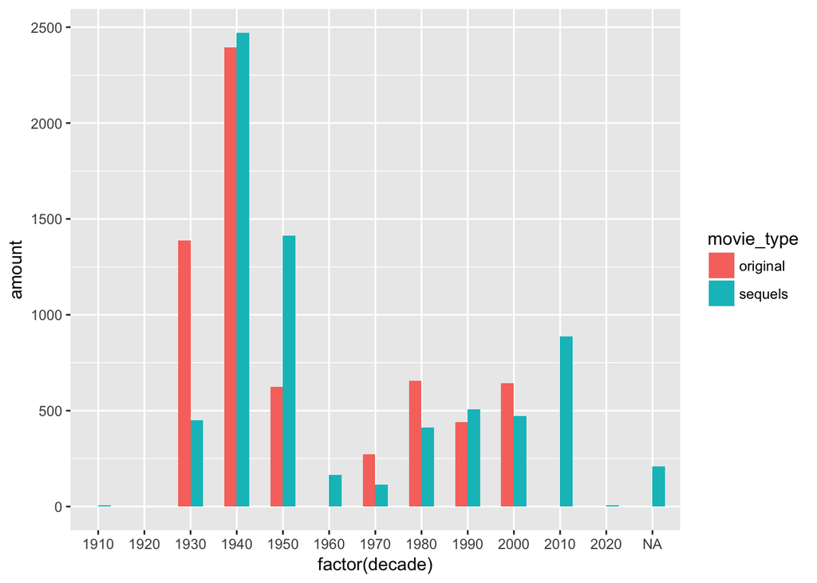

```r
# Bar graph (total)
library(tidyverse)
ggplot(d5, aes(factor(decade), amount, fill = movie_type)) +
  geom_bar(stat="identity", position = "dodge",width=.55)
```

```r
library(ggplot2)
library(ggthemes)
library(plyr)
library(scales)
p1 <- ggplot() +
geom_bar(aes(y = floor(percentage), x = decade, fill = type_of_movies), data =  d_percentage, stat="identity") +
geom_text(data=d_percentage, aes(x = decade, y = floor(percentage), label = paste0(floor(percentage),"%")), size=4)
```

**How has the ratio of original movies to sequels changed over time?**

We graphed the percentage of original versus sequel movies per decade. In this, having NA data was an issue, hence the missing columsn for several columns. Again, this data clearly demonstrates the increase in sequels during the 1950s, going from 50% to 69% of all movies.

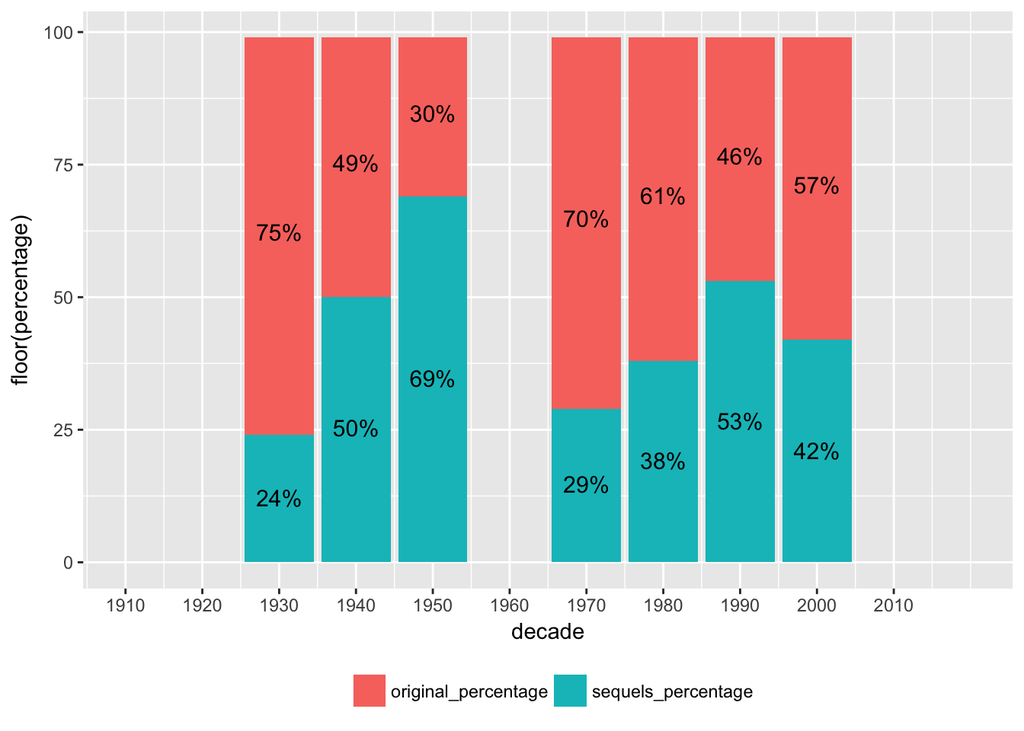

```r
#create a stacked bar plots
#P.S. the data of 1990 is missing

d_percentage <- ddply(d_percentage, .(decade),
                     transform, pos = cumsum(percentage) - (0.5 * percentage))
p3 <- ggplot() + geom_bar(aes(y = floor(percentage), x = decade, fill = type_of_movies), data = d_percentage, stat="identity") +
geom_text(data=d_percentage, aes(x = decade, y = pos, label = paste0(floor(percentage),"%")), size=4) +
theme(legend.position="bottom", legend.direction="horizontal",
                   legend.title = element_blank()) +
                   scale_x_continuous(breaks=seq(1890,2010,10))
p3
```

```r
#move the lable into the center of each bar
```

**How rapidly are sequels made to Comedy, Horror, and Romance films?**

In 1981, a serious economic crisis combined with tax breaks for studios meant that it was more profitable to invest in sequels, which had built-in success guaranteed, instead of less certain original films. This led to a dramatic decrease in the amount of years between the release of an original movie and its sequel. This shift is reflected by Comedy, Horror, and Romance movies. ```

```r
require(scales)

y1 <- big_data %>%
    group_by(original_year) %>%
   filter(original_year == 1980)
y1
```

```
## # A tibble: 37 x 9
## # Groups:   original_year [1]
##    movie_id linked_movie_id link_type_id
##       <int>           <int>        <int>
##  1  3260729         3260724            2
##  2  3270737         3270751            2
##  3  3293608         4400012            2
##  4  3369673         4403418            2
##  5  3394099         3394100            2
##  6  3416633         3416629            2
##  7  3416633         3642544            2
##  8  3416633         4008813            2
##  9  3416633         4265071            2
## 10  3416633         4451241            2
## # ... with 27 more rows, and 6 more variables: movie_title <chr>,
## #   linked_movie_title <chr>, original_year <int>, sequels_year <int>,
## #   year_difference <dbl>, genre <chr>
```

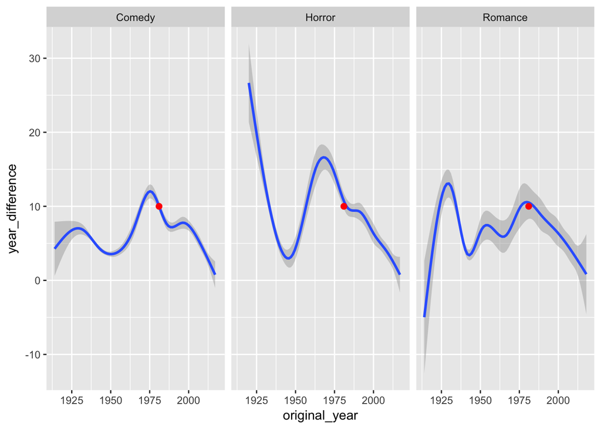

```r
ggplot(big_data, aes(x=original_year, y = year_difference))+
geom_smooth()+
annotate("point", x = 1981, y = 10, color = "red", size = 2) +

facet_wrap(~genre)
```